# Act Report on WeRateDogs Twitter Account Data Analysis

WeRateDogs is a Twitter account with funny and interesting tweets about dogs.

## Insights

### Frequency of Dog Ratings

A consideration of the frequency of dog rating was done which led to the visualization below.

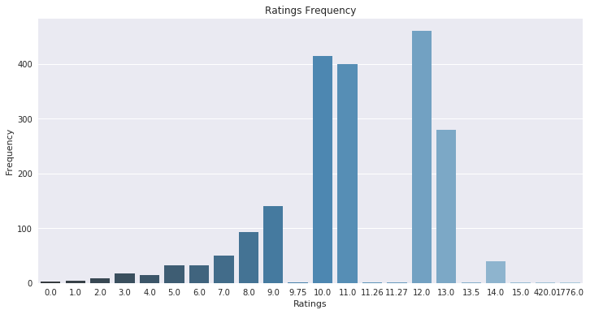

It's interesting to find out that some dogs have ratings more than 400/10. This could be an outlier.

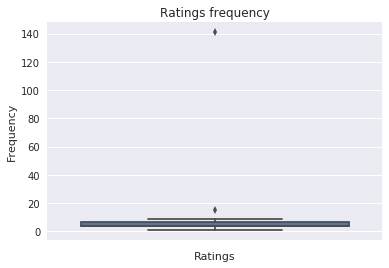

To identify these outliers, the images for these dogs were downloaded using the URLs provided in the dataset. The images downloaded are the followings.

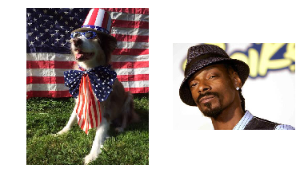

### The correlation between favorite dogs and retweet

To find out whether people retweeted dogs because they liked them, a correlation between retweets and favorite counts on the dogs was done which gave the output below.

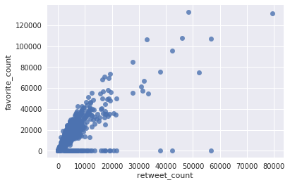

This seems to show a positive correlation, thus the more the favorite count of a dog, the more the retweet. To confirm this positive correlation, the diagram below was produced.

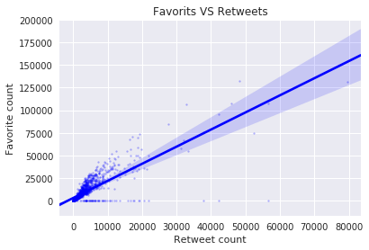

This shows a positive correlation between the favorite dog counts and the retweet which comfirms that the more favorite a dog is, the more people retweeted it.

### The most liked dog stage

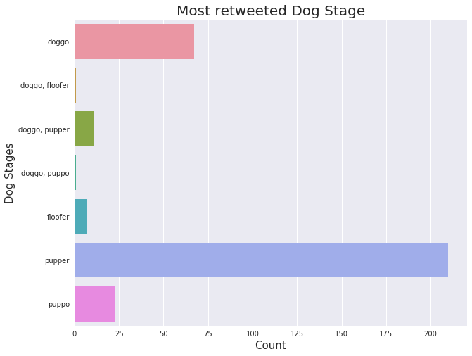

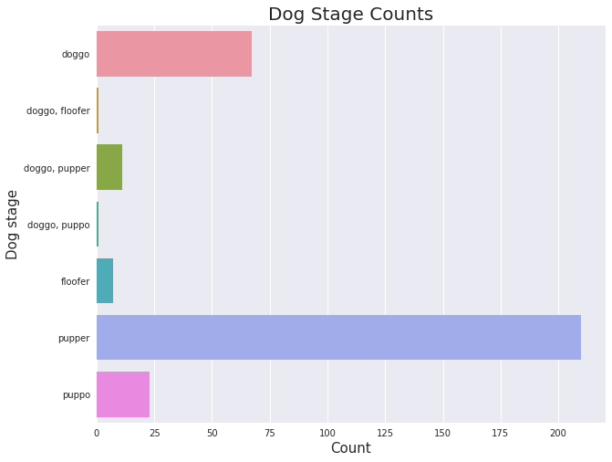

Tweet Source Count From the analysis, it was found that the Twitter for iPhone is the highest source of tweets, thus the large number of tweets were made using an iPhone.

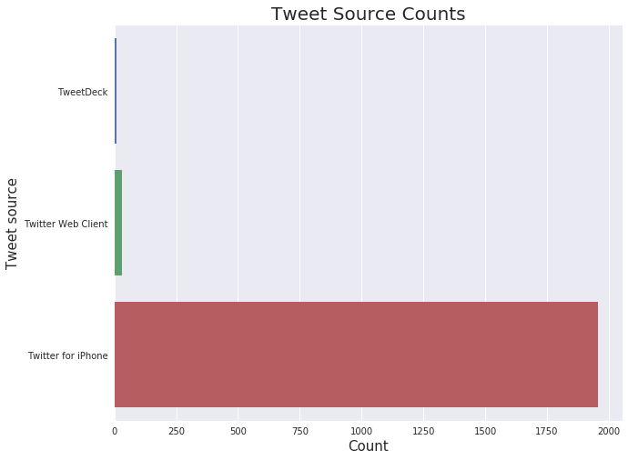

### Top 12 Most Used Dog Names

It was interesting to identify that the 12 most used dog names are Charlie, Lucy, Penny, Oliver, Tucker, Cooper, Bo, Sadie, Winston, Lola, Toby and Daisy as seen from the visualization below

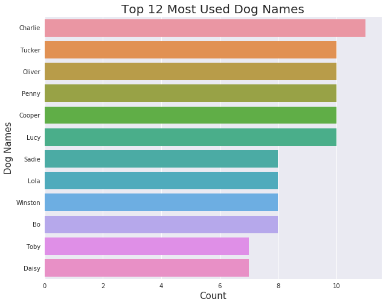